# Findings of 2000

The following variables are selected to see if the difference in income between men and women in 2000 vary depending on them:

1. race
2. age.start.drug.use.1998
3. household.children.number.1990
4. marital.status.2000
5. industry.2000
6. family.size.2000

# T-Test

Use t.test to test if there is significant difference in income between male and female in 2000.

```
##
##  Welch Two Sample t-test
##
## data:  income.2000 by gender
## t = -21.638, df = 4631.9, p-value < 2.2e-16
## alternative hypothesis: true difference in means is not equal to 0
## 95 percent confidence interval:
##  -19438.07 -16208.44
## sample estimates:
## mean in group Female   mean in group Male
##             22076.34             39899.60
```

**The outcome shows that the average different in income between male and female in 2000 is 1.7823310^{4} dollar, with the p value 0**

# Model 1

In the first model, data of those whose income is more than 0 but not top coded is used to do linear regression. The whole cleaned data frame is divided into two parts, one male and one female, and do regression seperately.

First test if income is normally distributed using qqplot.

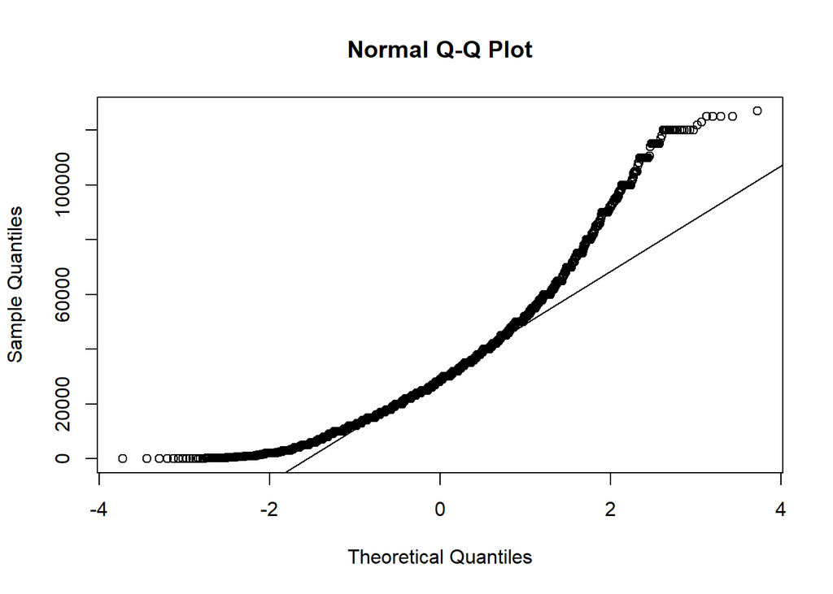

**The income is not normally distributed. So it should be dealt with. Many ways are tried, and doing square root is a good way.**

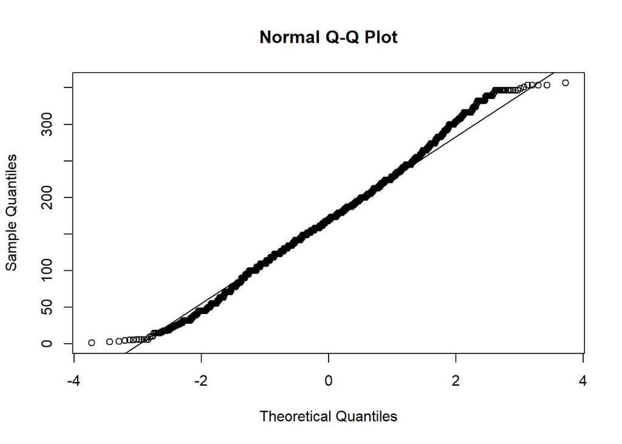

**Much better now.**

Divide the data frame into 2 by gender.

Then test if there are collinear variables. First in male.

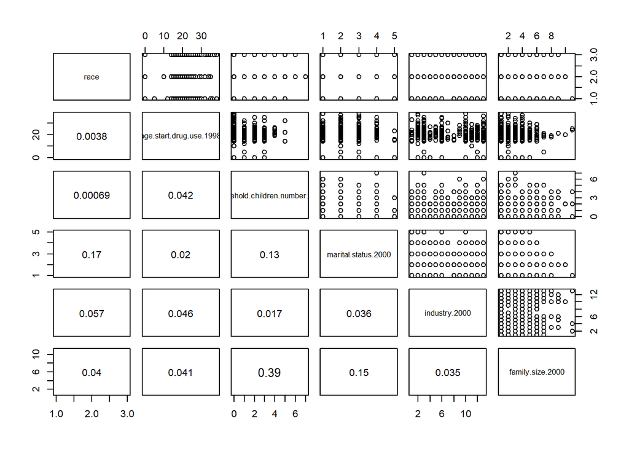

**From the plot, it can be seen that number of child and family size are collinear.**

Then test female.

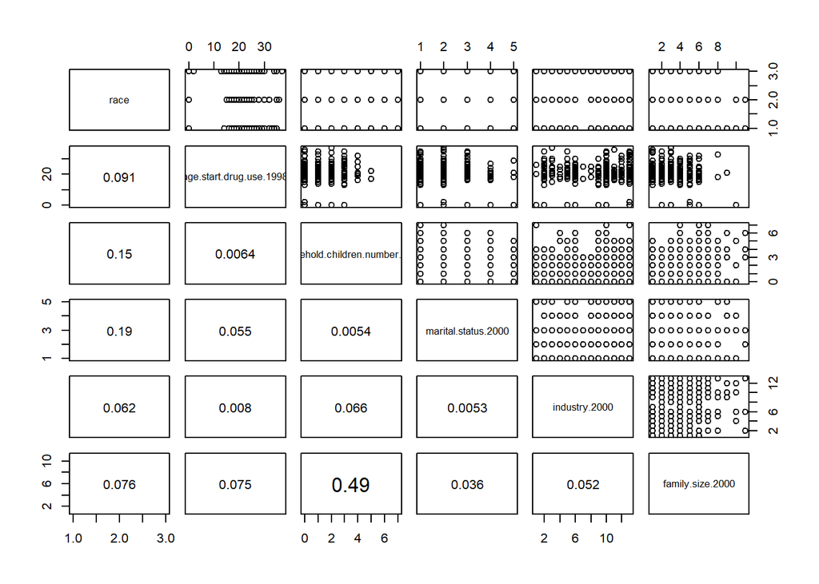

**From the plot, it can be seen number of child and family size are collinear, and more serious than male.**

**So remove number of child**

Now can do linear regression.  
Regression summary of male:

|  | Estimate | Std. Error | t value | Pr(>\|t\|) |
| --- | --- | --- | --- | --- |
| (Intercept) | 109.1440538 | 19.586369 | 5.5724496 | 0.0000000 |
| raceHispanic | 10.7135966 | 6.773132 | 1.5817789 | 0.1141616 |
| raceOther | 27.0530002 | 5.596139 | 4.8342259 | 0.0000017 |
| age.start.drug.use.1998 | -0.2402776 | 0.390240 | -0.6157176 | 0.5382855 |
| marital.status.2000Married | 38.1372694 | 6.935528 | 5.4988273 | 0.0000001 |
| marital.status.2000Never Married | -10.2465883 | 7.142532 | -1.4345876 | 0.1518610 |
| marital.status.2000Separated | 3.6096620 | 10.730331 | 0.3363980 | 0.7366738 |
| marital.status.2000Widowed | 22.8780807 | 29.129276 | 0.7853982 | 0.4324917 |
| industry.2000BUSINESS AND REPAIR SERVICES | 42.1149897 | 17.621184 | 2.3900204 | 0.0171167 |
| industry.2000CONSTRUCTION | 47.5581777 | 17.328760 | 2.7444651 | 0.0062197 |
| industry.2000ENTERTAINMENT AND RECREATION SERVICES | 52.0290997 | 21.538763 | 2.4156029 | 0.0159699 |
| industry.2000FINANCE,INSURANCE AND REAL ESTATE | 78.7046540 | 20.594477 | 3.8216388 | 0.0001446 |
| industry.2000MANUFACTURING | 58.9290115 | 17.040135 | 3.4582479 | 0.0005773 |
| industry.2000MINING | 44.2596894 | 30.271470 | 1.4620925 | 0.1441745 |
| industry.2000OTHERS | 79.9602140 | 32.865920 | 2.4329218 | 0.0152324 |
| industry.2000PERSONAL SERVICES | 57.3771976 | 25.212092 | 2.2757809 | 0.0231671 |
| industry.2000PROFESSIONAL AND RELATED SERVICES | 49.7740568 | 17.690456 | 2.8136107 | 0.0050393 |
| industry.2000PUBLIC ADMINISTRATION | 45.3343868 | 18.700546 | 2.4242279 | 0.0155988 |
| industry.2000TRANSPORTATION,COMMUNICATION,PUBLIC UTILITIES | 68.2859358 | 17.561491 | 3.8883904 | 0.0001107 |
| industry.2000WHOLESALE AND RETAIL TRADE | 35.2896442 | 17.306229 | 2.0391296 | 0.0418204 |
| family.size.2000 | -1.5402630 | 1.573076 | -0.9791411 | 0.3278560 |

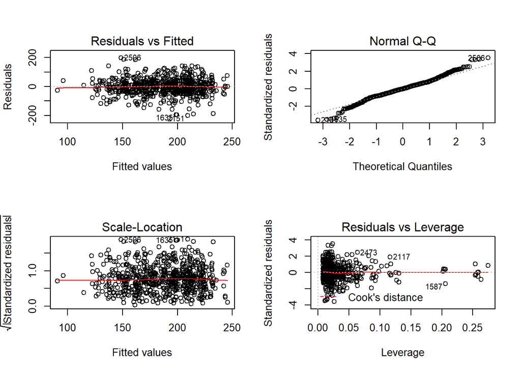

**From the 4 plots, it can be seen that the model is quite good.**

Regression summary of female:

|  | Estimate | Std. Error | t value | Pr(>\|t\|) |
| --- | --- | --- | --- | --- |
| (Intercept) | 131.0572658 | 36.4438667 | 3.5961405 | 0.0003620 |
| raceHispanic | 22.6899226 | 9.5505638 | 2.3757679 | 0.0179668 |
| raceOther | 24.9630400 | 7.9213314 | 3.1513692 | 0.0017432 |
| age.start.drug.use.1998 | -0.2359132 | 0.5227934 | -0.4512551 | 0.6520420 |
| marital.status.2000Married | -3.3466652 | 7.0302953 | -0.4760348 | 0.6343007 |
| marital.status.2000Never Married | -5.4102637 | 8.9094602 | -0.6072493 | 0.5440184 |
| marital.status.2000Separated | -1.8507370 | 13.1805276 | -0.1404145 | 0.8884008 |
| marital.status.2000Widowed | -32.6501203 | 35.4504116 | -0.9210082 | 0.3575825 |
| industry.2000BUSINESS AND REPAIR SERVICES | 30.7752572 | 35.3508431 | 0.8705664 | 0.3844954 |
| industry.2000CONSTRUCTION | -15.7006024 | 37.1783636 | -0.4223048 | 0.6730218 |
| industry.2000ENTERTAINMENT AND RECREATION SERVICES | 33.2605193 | 41.1017121 | 0.8092247 | 0.4188507 |
| industry.2000FINANCE,INSURANCE AND REAL ESTATE | 40.1217037 | 35.6216982 | 1.1263277 | 0.2606793 |
| industry.2000MANUFACTURING | 33.7550859 | 35.2423325 | 0.9577994 | 0.3387229 |
| industry.2000MINING | 6.8695739 | 52.1851445 | 0.1316385 | 0.8953342 |
| industry.2000OTHERS | 9.7863558 | 47.3365793 | 0.2067398 | 0.8363147 |
| industry.2000PERSONAL SERVICES | -24.3247426 | 35.7881014 | -0.6796880 | 0.4970819 |
| industry.2000PROFESSIONAL AND RELATED SERVICES | 26.7293136 | 34.5239968 | 0.7742242 | 0.4392401 |
| industry.2000PUBLIC ADMINISTRATION | 64.8566203 | 36.2255462 | 1.7903559 | 0.0741273 |
| industry.2000TRANSPORTATION,COMMUNICATION,PUBLIC UTILITIES | 34.2931492 | 35.8689062 | 0.9560690 | 0.3395953 |
| industry.2000WHOLESALE AND RETAIL TRADE | 9.9691267 | 34.8768238 | 0.2858381 | 0.7751451 |
| family.size.2000 | -3.8116364 | 2.1198503 | -1.7980687 | 0.0728945 |

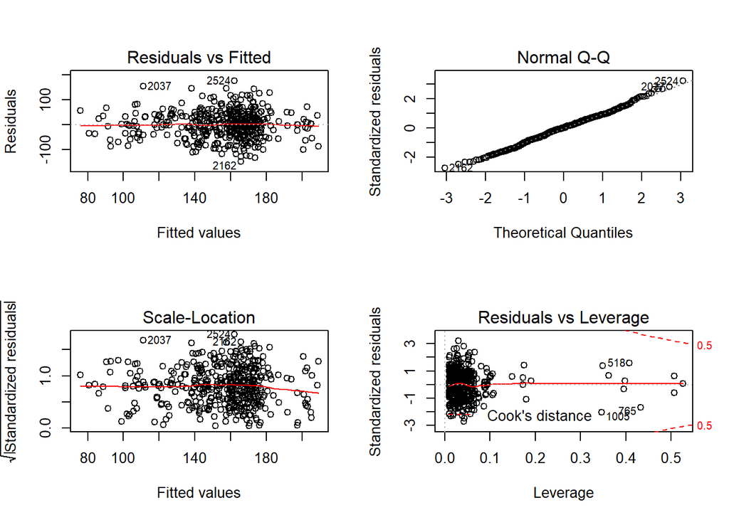

**From the 4 plots, it can be seen that the model is quite good.**  
**Significant variables (with p value <= 0.05) of male are shown below:**

|  | Estimate | Std. Error | t value | Pr(>\|t\|) |
| --- | --- | --- | --- | --- |
| (Intercept) | 109.14405 | 19.586369 | 5.572450 | 0.0000000 |
| raceOther | 27.05300 | 5.596139 | 4.834226 | 0.0000017 |
| marital.status.2000Married | 38.13727 | 6.935528 | 5.498827 | 0.0000001 |
| industry.2000BUSINESS AND REPAIR SERVICES | 42.11499 | 17.621184 | 2.390020 | 0.0171167 |
| industry.2000CONSTRUCTION | 47.55818 | 17.328760 | 2.744465 | 0.0062197 |
| industry.2000ENTERTAINMENT AND RECREATION SERVICES | 52.02910 | 21.538763 | 2.415603 | 0.0159699 |
| industry.2000FINANCE,INSURANCE AND REAL ESTATE | 78.70465 | 20.594477 | 3.821639 | 0.0001446 |
| industry.2000MANUFACTURING | 58.92901 | 17.040135 | 3.458248 | 0.0005773 |
| industry.2000OTHERS | 79.96021 | 32.865920 | 2.432922 | 0.0152324 |
| industry.2000PERSONAL SERVICES | 57.37720 | 25.212092 | 2.275781 | 0.0231671 |
| industry.2000PROFESSIONAL AND RELATED SERVICES | 49.77406 | 17.690456 | 2.813611 | 0.0050393 |
| industry.2000PUBLIC ADMINISTRATION | 45.33439 | 18.700546 | 2.424228 | 0.0155988 |
| industry.2000TRANSPORTATION,COMMUNICATION,PUBLIC UTILITIES | 68.28594 | 17.561491 | 3.888390 | 0.0001107 |
| industry.2000WHOLESALE AND RETAIL TRADE | 35.28964 | 17.306229 | 2.039130 | 0.0418204 |

**Significant variables (with p value <= 0.05) of female are shown below:**

|  | Estimate | Std. Error | t value | Pr(>\|t\|) |
| --- | --- | --- | --- | --- |
| (Intercept) | 131.05727 | 36.443867 | 3.596141 | 0.0003620 |
| raceHispanic | 22.68992 | 9.550564 | 2.375768 | 0.0179668 |
| raceOther | 24.96304 | 7.921331 | 3.151369 | 0.0017432 |

**From the 2 tables, it is found that the difference in income in 2000 vary depending on:**  
**1. Race. The income after square root of male of other race is 27.0530002 more than that of black male with a p value of 1.651311410^{-6}, while The income after square root of female of other race is 24.96304 more than that of black female with a p value of 0.0017432, so there is 2.0899602 more difference. The income after square root of hispanic female is 22.6899226 more than that of black female with a p value of 0.0179668. However, there is no significant in difference between hispanic male and black male in income after square root.**  
**2. Marital state. The income after square root of married male is 38.1372694 more than divorced male with a p value of 5.401007810^{-8}. However, there is no significant in difference between female of different marital state in income after square root.**  
**3. Industry. Male in some of different industries has significant different income after square root, while there is no significant difference between female in different industries in income after square root.**

# Model 2

In the second model, data of those whose income is more than 0 is used to create a logistic variable of whether the responder is of high income (whether the responder’s income is top coded), and do logistic regression.

Regression summary of male:

|  | Estimate | Std. Error | t value | Pr(>\|t\|) |
| --- | --- | --- | --- | --- |
| (Intercept) | -0.0257089 | 0.0661085 | -0.3888900 | 0.6974734 |
| raceHispanic | 0.0236668 | 0.0226153 | 1.0464960 | 0.2956862 |
| raceOther | 0.0270710 | 0.0187409 | 1.4444865 | 0.1490409 |
| age.start.drug.use.1998 | -0.0010476 | 0.0013114 | -0.7988492 | 0.4246435 |
| marital.status.2000Married | 0.0555097 | 0.0232596 | 2.3865221 | 0.0172681 |
| marital.status.2000Never Married | 0.0082143 | 0.0240201 | 0.3419762 | 0.7324694 |
| marital.status.2000Separated | 0.0014125 | 0.0362766 | 0.0389367 | 0.9689517 |
| marital.status.2000Widowed | -0.0062495 | 0.0986140 | -0.0633733 | 0.9494870 |
| industry.2000BUSINESS AND REPAIR SERVICES | 0.0664869 | 0.0594272 | 1.1187966 | 0.2636032 |
| industry.2000CONSTRUCTION | 0.0232103 | 0.0586250 | 0.3959113 | 0.6922887 |
| industry.2000ENTERTAINMENT AND RECREATION SERVICES | 0.0562511 | 0.0721436 | 0.7797105 | 0.4358197 |
| industry.2000FINANCE,INSURANCE AND REAL ESTATE | 0.1941164 | 0.0671623 | 2.8902572 | 0.0039661 |
| industry.2000MANUFACTURING | 0.0264827 | 0.0576409 | 0.4594430 | 0.6460559 |
| industry.2000MINING | -0.0231752 | 0.1025110 | -0.2260749 | 0.8212079 |
| industry.2000OTHERS | 0.0006601 | 0.1113017 | 0.0059308 | 0.9952696 |
| industry.2000PERSONAL SERVICES | 0.0334687 | 0.0853680 | 0.3920518 | 0.6951370 |
| industry.2000PROFESSIONAL AND RELATED SERVICES | 0.0616048 | 0.0596443 | 1.0328696 | 0.3020147 |
| industry.2000PUBLIC ADMINISTRATION | -0.0066013 | 0.0633297 | -0.1042365 | 0.9170110 |
| industry.2000TRANSPORTATION,COMMUNICATION,PUBLIC UTILITIES | 0.0145199 | 0.0594248 | 0.2443414 | 0.8070366 |
| industry.2000WHOLESALE AND RETAIL TRADE | 0.0579131 | 0.0584528 | 0.9907677 | 0.3221347 |
| family.size.2000 | -0.0031013 | 0.0052638 | -0.5891616 | 0.5559392 |

Regression summary of female:

|  | Estimate | Std. Error | z value | Pr(>\|z\|) |
| --- | --- | --- | --- | --- |
| (Intercept) | -41.7265919 | 3.966298e+04 | -0.0010520 | 0.9991606 |
| raceHispanic | -1.2130271 | 9.457132e+03 | -0.0001283 | 0.9998977 |
| raceOther | 18.0564077 | 6.303008e+03 | 0.0028647 | 0.9977143 |
| age.start.drug.use.1998 | 0.0971570 | 2.008506e-01 | 0.4837279 | 0.6285790 |
| marital.status.2000Married | 20.6619148 | 5.843819e+03 | 0.0035357 | 0.9971789 |
| marital.status.2000Never Married | 0.2553098 | 9.085884e+03 | 0.0000281 | 0.9999776 |
| marital.status.2000Separated | 2.3490060 | 1.398922e+04 | 0.0001679 | 0.9998660 |
| marital.status.2000Widowed | 19.5031656 | 4.431793e+04 | 0.0004401 | 0.9996489 |
| industry.2000BUSINESS AND REPAIR SERVICES | -18.7134603 | 4.003328e+04 | -0.0004674 | 0.9996270 |
| industry.2000CONSTRUCTION | -19.4939613 | 4.520488e+04 | -0.0004312 | 0.9996559 |
| industry.2000ENTERTAINMENT AND RECREATION SERVICES | -17.3258061 | 4.723870e+04 | -0.0003668 | 0.9997074 |
| industry.2000FINANCE,INSURANCE AND REAL ESTATE | 2.4070147 | 3.872046e+04 | 0.0000622 | 0.9999504 |
| industry.2000MANUFACTURING | -18.4131104 | 3.995476e+04 | -0.0004608 | 0.9996323 |
| industry.2000MINING | -19.6693270 | 6.371255e+04 | -0.0003087 | 0.9997537 |
| industry.2000OTHERS | -16.3729411 | 5.401784e+04 | -0.0003031 | 0.9997582 |
| industry.2000PERSONAL SERVICES | -16.7268976 | 4.042737e+04 | -0.0004138 | 0.9996699 |
| industry.2000PROFESSIONAL AND RELATED SERVICES | 0.2160639 | 3.872046e+04 | 0.0000056 | 0.9999955 |
| industry.2000PUBLIC ADMINISTRATION | -18.3454669 | 4.096221e+04 | -0.0004479 | 0.9996427 |
| industry.2000TRANSPORTATION,COMMUNICATION,PUBLIC UTILITIES | 3.2419577 | 3.872046e+04 | 0.0000837 | 0.9999332 |
| industry.2000WHOLESALE AND RETAIL TRADE | -17.7224863 | 3.945895e+04 | -0.0004491 | 0.9996416 |
| family.size.2000 | -1.2073043 | 6.666733e-01 | -1.8109386 | 0.0701504 |

**Significant variables (with p value <= 0.05) of male are shown below:**

|  | Estimate | Std. Error | t value | Pr(>\|t\|) |
| --- | --- | --- | --- | --- |
| marital.status.2000Married | 0.0555097 | 0.0232596 | 2.386522 | 0.0172681 |
| industry.2000FINANCE,INSURANCE AND REAL ESTATE | 0.1941164 | 0.0671623 | 2.890257 | 0.0039661 |

**Significant variables (with p value <= 0.05) of female are shown below:**

| Estimate | Std. Error | z value | Pr(>\|z\|) |
| --- | --- | --- | --- |

**From the 2 tables, it is found that whether one will have top 2% income in 2000 vary depending on:**  
**1. Marital state. For married male, the odds of having an income of top 2% increase by a factor of 1.0570792 with a p value of 0.0172681 compared to divorced male. However, it is not significant in female.**  
**2. Industry. For male in finance, insurance and real estate, the odds of having an income of top 2% increase by a factor of 1.2142376 with a p value of 0.0039661 compared to male in agriculture, forestry and fisheries. However, it is not significant in female.**

# Model 3

In the third model, every data is used to create a logistic variable of whether the responder has income (whether the income is more than 0), and do logistic regression.

Regression summary of male:

|  | Estimate | Std. Error | t value | Pr(>\|t\|) |
| --- | --- | --- | --- | --- |
| (Intercept) | 0.9105562 | 0.0709455 | 12.8345843 | 0.0000000 |
| raceHispanic | 0.0474665 | 0.0242508 | 1.9573153 | 0.0506795 |
| raceOther | 0.0626174 | 0.0200100 | 3.1293113 | 0.0018198 |
| age.start.drug.use.1998 | -0.0015365 | 0.0014169 | -1.0843923 | 0.2785380 |
| marital.status.2000Married | 0.0111369 | 0.0253533 | 0.4392675 | 0.6605937 |
| marital.status.2000Never Married | -0.0574252 | 0.0257425 | -2.2307526 | 0.0259913 |
| marital.status.2000Separated | 0.0433131 | 0.0396720 | 1.0917807 | 0.2752787 |
| marital.status.2000Widowed | 0.0328368 | 0.1097845 | 0.2991019 | 0.7649448 |
| industry.2000BUSINESS AND REPAIR SERVICES | -0.0046533 | 0.0635887 | -0.0731780 | 0.9416839 |
| industry.2000CONSTRUCTION | -0.0053677 | 0.0627496 | -0.0855418 | 0.9318534 |
| industry.2000ENTERTAINMENT AND RECREATION SERVICES | 0.0388116 | 0.0775571 | 0.5004267 | 0.6169209 |
| industry.2000FINANCE,INSURANCE AND REAL ESTATE | 0.0083534 | 0.0719643 | 0.1160774 | 0.9076222 |
| industry.2000MANUFACTURING | 0.0641695 | 0.0618551 | 1.0374164 | 0.2998749 |
| industry.2000MINING | 0.0514845 | 0.1130152 | 0.4555538 | 0.6488422 |
| industry.2000OTHERS | 0.0492604 | 0.1228661 | 0.4009273 | 0.6885874 |
| industry.2000PERSONAL SERVICES | -0.0760995 | 0.0881374 | -0.8634194 | 0.3881819 |
| industry.2000PROFESSIONAL AND RELATED SERVICES | 0.0773752 | 0.0642050 | 1.2051264 | 0.2285331 |
| industry.2000PUBLIC ADMINISTRATION | 0.0117710 | 0.0681333 | 0.1727646 | 0.8628829 |
| industry.2000TRANSPORTATION,COMMUNICATION,PUBLIC UTILITIES | 0.0549530 | 0.0638518 | 0.8606343 | 0.3897135 |
| industry.2000WHOLESALE AND RETAIL TRADE | 0.0070475 | 0.0625744 | 0.1126267 | 0.9103565 |
| family.size.2000 | 0.0006542 | 0.0057110 | 0.1145543 | 0.9088289 |

Regression summary of female:

|  | Estimate | Std. Error | z value | Pr(>\|z\|) |
| --- | --- | --- | --- | --- |
| (Intercept) | 16.8274365 | 3411.2675456 | 0.0049329 | 0.9960641 |
| raceHispanic | 0.7886211 | 0.6922529 | 1.1392096 | 0.2546158 |
| raceOther | 0.5525491 | 0.5157856 | 1.0712768 | 0.2840450 |
| age.start.drug.use.1998 | 0.0443216 | 0.0318040 | 1.3935856 | 0.1634428 |
| marital.status.2000Married | -0.2033040 | 0.4798672 | -0.4236672 | 0.6718085 |
| marital.status.2000Never Married | 0.7132906 | 0.7560708 | 0.9434178 | 0.3454673 |
| marital.status.2000Separated | 16.1804541 | 1324.9121516 | 0.0122125 | 0.9902561 |
| marital.status.2000Widowed | 15.5491140 | 3211.6876180 | 0.0048414 | 0.9961371 |
| industry.2000BUSINESS AND REPAIR SERVICES | -15.8655228 | 3411.2675140 | -0.0046509 | 0.9962891 |
| industry.2000CONSTRUCTION | 0.2960495 | 3876.7609013 | 0.0000764 | 0.9999391 |
| industry.2000ENTERTAINMENT AND RECREATION SERVICES | 0.6252231 | 4312.4811402 | 0.0001450 | 0.9998843 |
| industry.2000FINANCE,INSURANCE AND REAL ESTATE | -14.2789686 | 3411.2676383 | -0.0041858 | 0.9966602 |
| industry.2000MANUFACTURING | -14.9976295 | 3411.2675475 | -0.0043965 | 0.9964921 |
| industry.2000MINING | 0.2469701 | 5706.2459670 | 0.0000433 | 0.9999655 |
| industry.2000OTHERS | 0.0973514 | 4892.9739986 | 0.0000199 | 0.9999841 |
| industry.2000PERSONAL SERVICES | -15.7266562 | 3411.2675296 | -0.0046102 | 0.9963216 |
| industry.2000PROFESSIONAL AND RELATED SERVICES | -14.9400258 | 3411.2675095 | -0.0043796 | 0.9965056 |
| industry.2000PUBLIC ADMINISTRATION | -15.9085409 | 3411.2675498 | -0.0046635 | 0.9962791 |
| industry.2000TRANSPORTATION,COMMUNICATION,PUBLIC UTILITIES | -15.5254353 | 3411.2675449 | -0.0045512 | 0.9963687 |
| industry.2000WHOLESALE AND RETAIL TRADE | -15.0736756 | 3411.2675233 | -0.0044188 | 0.9964743 |
| family.size.2000 | -0.1356513 | 0.1377284 | -0.9849192 | 0.3246638 |

**Significant variables (with p value <= 0.05) of male are shown below:**

|  | Estimate | Std. Error | t value | Pr(>\|t\|) |
| --- | --- | --- | --- | --- |
| (Intercept) | 0.9105562 | 0.0709455 | 12.834584 | 0.0000000 |
| raceOther | 0.0626174 | 0.0200100 | 3.129311 | 0.0018198 |
| marital.status.2000Never Married | -0.0574252 | 0.0257425 | -2.230753 | 0.0259913 |

**Significant variables (with p value <= 0.05) of female are shown below:**

| Estimate | Std. Error | z value | Pr(>\|z\|) |
| --- | --- | --- | --- |

**From the 2 tables, it is found that whether one will have income in 2000 vary depending on:**  
**1. Race. For male of other race compared to black, the odds of having no income decrease by a factor of 1.0646194 with a p value of 0.0018198 . There is no such significant relationship of female.**  
**2. Marital state. For never married male compared to divorced, the odds of having no income increase by a factor of -0.9441925 with a p value of 0.0259913 compared to divorced male. However, it is not significant in female.**

# Interation model

Similar with income in 1990, all the variables mentioned above related to year 2000 are taken into consideration here at first. The variabels needed are selected into `clean.nlsy.income1990.1`. For the income of 1990, the top 2% and zero income data is excluded.

To test whether the income.2000 in clean.nlsy.income2000.1 is normally distributed, `qqmorm()` and `qqline()` are used here.

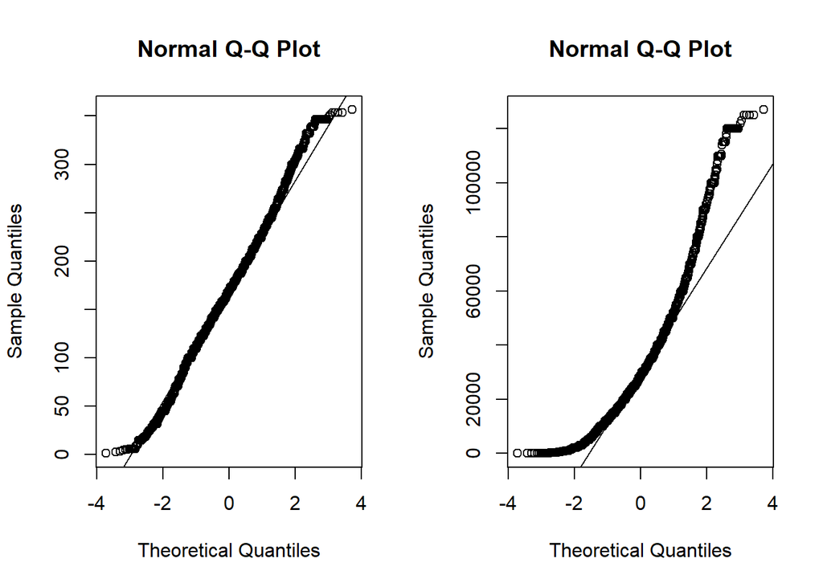

From the figure above, `income.2000^0.5` (left one) is more normally distributed than `income.2000` (right one). Therefore, `income.2000^0.5` is used in this interaction regression model.

Make each variable interact with `gender`. The summary and plots are as follows:

```
##
## Call:
## lm(formula = income.2000^0.5 ~ marital.status.2000 * gender +
##     race * gender + family.size.2000 * gender, data = clean.nlsy.income2000.1)
##
## Residuals:
##      Min       1Q   Median       3Q      Max
## -207.968  -33.979   -0.874   34.152  204.248
##
## Coefficients:
##                                             Estimate Std. Error t value
## (Intercept)                                  168.600      3.925  42.950
## marital.status.2000Married                     3.217      3.122   1.030
## marital.status.2000Never Married              -2.740      3.830  -0.715
## marital.status.2000Separated                 -20.066      5.046  -3.976
## marital.status.2000Widowed                   -13.782     10.064  -1.369
## genderMale                                   -11.773      5.545  -2.123
## raceHispanic                                   4.979      3.334   1.493
## raceOther                                      5.036      2.701   1.865
## family.size.2000                              -6.183      0.797  -7.757
## marital.status.2000Married:genderMale         29.677      4.915   6.038
## marital.status.2000Never Married:genderMale   -2.586      5.535  -0.467
## marital.status.2000Separated:genderMale       11.943      7.863   1.519
## marital.status.2000Widowed:genderMale         31.377     20.567   1.526
## genderMale:raceHispanic                        7.734      4.732   1.634
## genderMale:raceOther                          21.907      3.822   5.732
## genderMale:family.size.2000                    4.716      1.160   4.064
##                                             Pr(>|t|)
## (Intercept)                                  < 2e-16 ***
## marital.status.2000Married                    0.3028
## marital.status.2000Never Married              0.4744
## marital.status.2000Separated                7.10e-05 ***
## marital.status.2000Widowed                    0.1709
## genderMale                                    0.0338 *
## raceHispanic                                  0.1355
## raceOther                                     0.0623 .
## family.size.2000                            1.04e-14 ***
## marital.status.2000Married:genderMale       1.67e-09 ***
## marital.status.2000Never Married:genderMale   0.6404
## marital.status.2000Separated:genderMale       0.1289
## marital.status.2000Widowed:genderMale         0.1272
## genderMale:raceHispanic                       0.1022
## genderMale:raceOther                        1.05e-08 ***
## genderMale:family.size.2000                 4.90e-05 ***
## ---
## Signif. codes:  0 '***' 0.001 '**' 0.01 '*' 0.05 '.' 0.1 ' ' 1
##
## Residual standard error: 55.8 on 5052 degrees of freedom
## Multiple R-squared:  0.1731, Adjusted R-squared:  0.1707
## F-statistic: 70.51 on 15 and 5052 DF,  p-value: < 2.2e-16
```

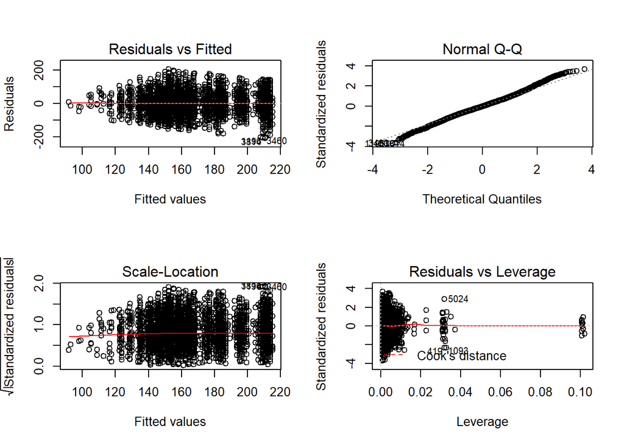

There are three interaction terms indicate the significant association to the difference of income between male and female.

- `marital.status.2000Married:genderMale`: For married male and female, the difference of `income.2000^0.5` between them increases 29.68.
- `genderMale:raceOther`: the **Other race** significantly incluence the income difference between male and femal. In “Other” race, the **difference** of `income.2000^0.5` between male and femal increases 21.91. Therefore, the income difference between male and femal in “Other” race will increase 7453.08.
- `genderMale:family.size.2000`: since the `family.size.2000` is a numeric variable, the interpretation of this interaction term would be a little bit different. The coefficient of this term means that each time when the family size increases **one**, the difference of `income.2000^0.5` between male and female increases 4.72.